# Analysis of Attrition Data: Main factors that affect Employee Turnover

Chaoshun Hu, Mahesh Kuklani, Rene Pineda

August 7, 2018

## Thanks to RPubs Raju Rimal for this function

```r
diagPlot<-function(model){
    p1<-ggplot(model, aes(.fitted, .resid))+geom_point()
    p1<-p1+stat_smooth(method="loess")+geom_hline(yintercept=0, col="red", linetype="dashed")
    p1<-p1+xlab("Fitted values")+ylab("Residuals")
    p1<-p1+ggtitle("Residual vs Fitted Plot")+theme_bw()

    p2<-ggplot(model, aes(qqnorm(.stdresid)[[1]], .stdresid))+geom_point(na.rm = TRUE)
    p2<-p2+geom_abline(aes(qqline(.stdresid)))+xlab("Theoretical Quantiles")+ylab("Standardized Residuals")
    p2<-p2+ggtitle("Normal Q-Q")+theme_bw()

    p3<-ggplot(model, aes(.fitted, sqrt(abs(.stdresid))))+geom_point(na.rm=TRUE)
    p3<-p3+stat_smooth(method="loess", na.rm = TRUE)+xlab("Fitted Value")
    p3<-p3+ylab(expression(sqrt("|Standardized residuals|")))
    p3<-p3+ggtitle("Scale-Location")+theme_bw()

    p4<-ggplot(model, aes(seq_along(.cooksd), .cooksd))+geom_bar(stat="identity", position="identity")
    p4<-p4+xlab("Obs. Number")+ylab("Cook's distance")
    p4<-p4+ggtitle("Cook's distance")+theme_bw()

    p5<-ggplot(model, aes(.hat, .stdresid))+geom_point(aes(size=.cooksd), na.rm=TRUE)
    p5<-p5+stat_smooth(method="loess", na.rm=TRUE)
    p5<-p5+xlab("Leverage")+ylab("Standardized Residuals")
    p5<-p5+ggtitle("Residual vs Leverage Plot")
    p5<-p5+scale_size_continuous("Cook's Distance", range=c(1,5))
    p5<-p5+theme_bw()+theme(legend.position="bottom")

    p6<-ggplot(model, aes(.hat, .cooksd))+geom_point(na.rm=TRUE)+stat_smooth(method="loess", na.rm=TRUE)
    p6<-p6+xlab("Leverage hii")+ylab("Cook's Distance")
    p6<-p6+ggtitle("Cook's dist vs Leverage hii/(1-hii)")
    p6<-p6+geom_abline(slope=seq(0,3,0.5), color="gray", linetype="dashed")
    p6<-p6+theme_bw()

    return(list(rvfPlot=p1, qqPlot=p2, sclLocPlot=p3, cdPlot=p4, rvlevPlot=p5, cvlPlot=p6))
}
```

## Introduction

Voluntary attrition occurs when an employee leaves a company of his or her own accord. This can occur when employees leave their current positions for another job, leave the workforce entirely, or retire. The reasons for leaving a company can vary from personal reasons, such as desiring career advancement or moving to a different city, to company-based reasons, such as an unwanted change in company structure or management.

A high turnover rate typically means working conditions are not optimal, pay is below market average, or staffers are not well trained. Concurrently, a low turnover rate is indicative of a work environment where staffers feel appreciated, work as a team, have room to move up the corporate ladder, and are satisfied with their jobs.

Source: CompData’s 2016 edition of their annual BenchmarkPro Survey

Companies usually would like to decrease their voluntary turnover rates due to numerous unfavorable impacts:

- Overall poor company performance
- Low employee morale
- Operating and monetary costs (severance payments, cost of re-hiring and re-training)
- Money invested in the employees that leave the company can’t be recovered
- The decrease in the workforce causes remaining employees to work on the slack left behind- mostly performing the task they are not completely trained to perform or are not the best suited
- The situation may get out of control and lead to mass exit of employees, disabling the ability of the company to perform at a high level.

In order to deal with employee attrition and deal with its negative impacts, it is important to know about the most important causes of Attrition. The purpose of this analysis is to try to dilucidate what are the most important factors that contribute to attrition, amongst the many factors that affect an employee’s environment and satisfaction. Once these factors are determined, a company can take actions to control them.

### 2. Loading and cleaning the data

**a Read the csv into R and take a look at the data set. Output how many rows and columns the data.frame is.**

```r
dim(talentManage)
```

```
## [1] 1470   35
```

The `talentManage` data frame has 1470 rows and 35 columns.

**b The column names are either too much or not enough. Change the column names so that they do not have spaces, underscores, slashes, and the like. All column names should be under 12 characters. Make sure you’re updating your codebook with information on the tidied data set as well.**

We use an R function to automatically abbreviate the variable names:

```r
#List column names
colnames(talentManage)
```

```
##  [1] "Age"                      "Attrition"
##  [3] "BusinessTravel"           "DailyRate"
##  [5] "Department"               "DistanceFromHome"
##  [7] "Education"                "EducationField"
##  [9] "EmployeeCount"            "EmployeeNumber"
## [11] "EnvironmentSatisfaction"  "Gender"
## [13] "HourlyRate"               "JobInvolvement"
## [15] "JobLevel"                 "JobRole"
## [17] "JobSatisfaction"          "MaritalStatus"
## [19] "MonthlyIncome"            "MonthlyRate"
## [21] "NumCompaniesWorked"       "Over18"
## [23] "OverTime"                 "PercentSalaryHike"
## [25] "PerformanceRating"        "RelationshipSatisfaction"
## [27] "StandardHours"            "StockOptionLevel"
## [29] "TotalWorkingYears"        "TrainingTimesLastYear"
## [31] "WorkLifeBalance"          "YearsAtCompany"
## [33] "YearsInCurrentRole"       "YearsSinceLastPromotion"
## [35] "YearsWithCurrManager"
```

```r
#Abbreviate column names
colnames(talentManage)=abbreviate(colnames(talentManage), method=c("both.sides"),minlength = 11)
```

We will now list the column names again and count the characters to confirm confirm that none exceeds the 12-character limit

```r
columns <- colnames(talentManage)
columns
```

```
##  [1] "Age"         "Attrition"   "BusinssTrvl" "DailyRate"   "Department"
##  [6] "DistncFrmHm" "Education"   "EducatinFld" "EmployeeCnt" "EmployeNmbr"
## [11] "EnvrnmntSts" "Gender"      "HourlyRate"  "JobInvlvmnt" "JobLevel"
## [16] "JobRole"     "JobSatsfctn" "MaritalStts" "MonthlyIncm" "MonthlyRate"
## [21] "NmCmpnsWrkd" "Over18"      "OverTime"    "PrcntSlryHk" "PrfrmncRtng"
## [26] "RltnshpStsf" "StandardHrs" "StckOptnLvl" "TtlWrkngYrs" "TrnngTmsLsY"
## [31] "WorkLifBlnc" "YersAtCmpny" "YrsInCrrntR" "YrsSncLstPr" "YrsWthCrrMn"
```

```r
sapply(columns, nchar)
```

```
##         Age   Attrition BusinssTrvl   DailyRate  Department DistncFrmHm
##           3           9          11           9          10          11
##   Education EducatinFld EmployeeCnt EmployeNmbr EnvrnmntSts      Gender
##           9          11          11          11          11           6
##  HourlyRate JobInvlvmnt    JobLevel     JobRole JobSatsfctn MaritalStts
##          10          11           8           7          11          11
## MonthlyIncm MonthlyRate NmCmpnsWrkd      Over18    OverTime PrcntSlryHk
##          11          11          11           6           8          11
## PrfrmncRtng RltnshpStsf StandardHrs StckOptnLvl TtlWrkngYrs TrnngTmsLsY
##          11          11          11          11          11          11
## WorkLifBlnc YersAtCmpny YrsInCrrntR YrsSncLstPr YrsWthCrrMn
##          11          11          11          11          11
```

**c. Some columns are, due to Qualtrics, malfunctioning.**

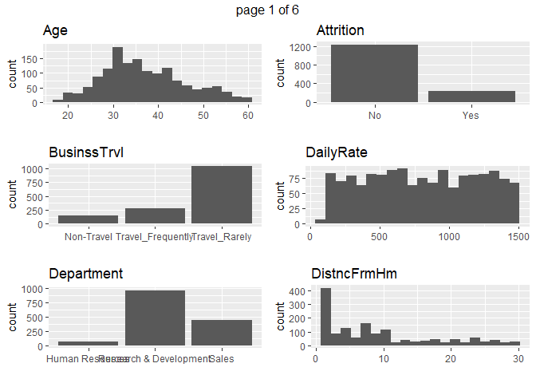

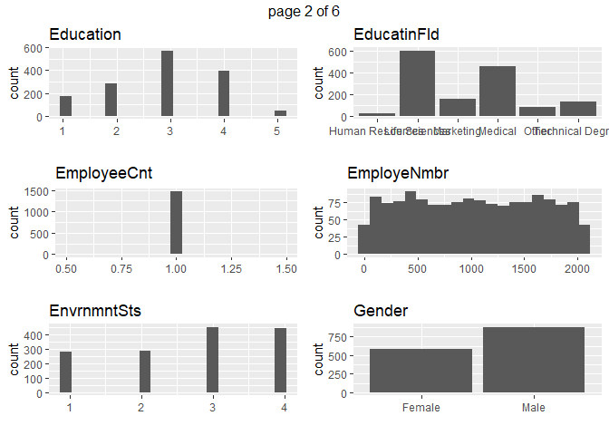

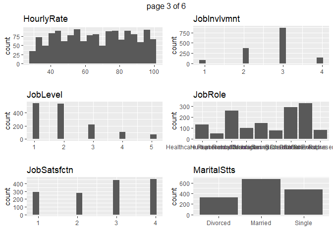

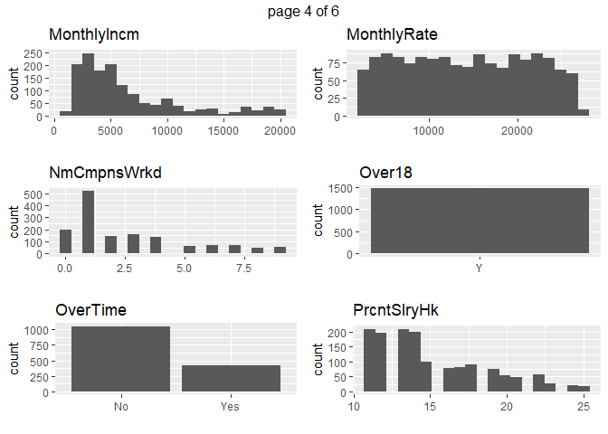

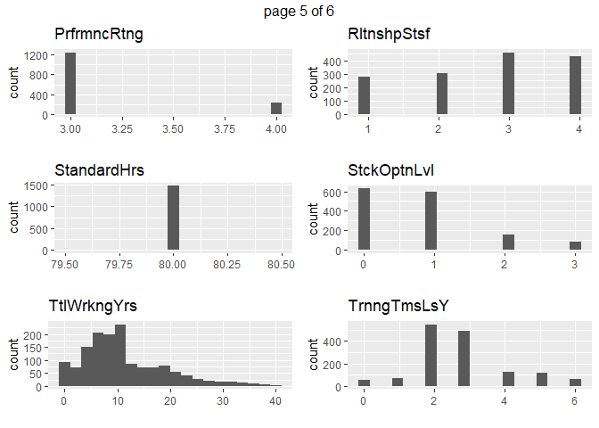

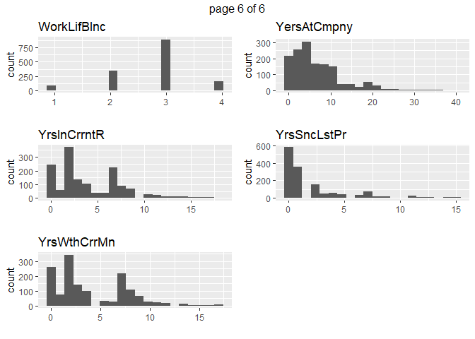

```r
#basic statistics (EDA)
visualize(talentManage)
```

**d. Make sure your columns are the proper data types (i.e., numeric, character, etc.). If they are incorrect, convert them.**

```r
#copy the data to a new dataset talentManage1 for analysis
talentManage1 <- talentManage

str(talentManage1)
```

```
## 'data.frame':    1470 obs. of  35 variables:
##  $ Age        : int  41 49 37 33 27 32 59 30 38 36 ...
##  $ Attrition  : Factor w/ 2 levels "No","Yes": 2 1 2 1 1 1 1 1 1 1 ...
##  $ BusinssTrvl: Factor w/ 3 levels "Non-Travel","Travel_Frequently",..: 3 2 3 2 3 2 3 3 2 3 ...
##  $ DailyRate  : int  1102 279 1373 1392 591 1005 1324 1358 216 1299 ...
##  $ Department : Factor w/ 3 levels "Human Resources",..: 3 2 2 2 2 2 2 2 2 2 ...
##  $ DistncFrmHm: int  1 8 2 3 2 2 3 24 23 27 ...
##  $ Education  : int  2 1 2 4 1 2 3 1 3 3 ...
##  $ EducatinFld: Factor w/ 6 levels "Human Resources",..: 2 2 5 2 4 2 4 2 2 4 ...
##  $ EmployeeCnt: int  1 1 1 1 1 1 1 1 1 1 ...
##  $ EmployeNmbr: int  1 2 4 5 7 8 10 11 12 13 ...
##  $ EnvrnmntSts: int  2 3 4 4 1 4 3 4 4 3 ...
##  $ Gender     : Factor w/ 2 levels "Female","Male": 1 2 2 1 2 2 1 2 2 2 ...
##  $ HourlyRate : int  94 61 92 56 40 79 81 67 44 94 ...
##  $ JobInvlvmnt: int  3 2 2 3 3 3 4 3 2 3 ...
```

[output cut: 21 more lines]

```r
#Check the 'class' of each variable column
lapply(talentManage, class)
```

```
## $Age
## [1] "integer"
##
## $Attrition
## [1] "factor"
##
## $BusinssTrvl
## [1] "factor"
##
## $DailyRate
## [1] "integer"
##
## $Department
## [1] "factor"
##
## $DistncFrmHm
## [1] "integer"
##
## $Education
## [1] "integer"
##
## $EducatinFld
## [1] "factor"
##
## $EmployeeCnt
## [1] "integer"
##
## $EmployeNmbr
## [1] "integer"
##
## $EnvrnmntSts
## [1] "integer"
##
## $Gender
## [1] "factor"
##
## $HourlyRate
## [1] "integer"
##
## $JobInvlvmnt
```

[output cut: 49 more lines]

```
##
## $WorkLifBlnc
## [1] "integer"
##
## $YersAtCmpny
## [1] "integer"
##
## $YrsInCrrntR
## [1] "integer"
##
## $YrsSncLstPr
## [1] "integer"
##
## $YrsWthCrrMn
## [1] "integer"
```

```r
#Recode variables from 'numeric' to 'factor'
talentManage[,7] <- factor(talentManage[,7], labels = c("Below College", "College", "Bachelor", "Master", "Doctor"), ordered = TRUE)
talentManage[,11] <- factor(talentManage[,11], labels = c('Low', 'Medium', 'High', 'Very High'), ordered = TRUE)
talentManage[,14] <- factor(talentManage[,14], labels = c('Low', 'Medium', 'High', 'Very High'), ordered = TRUE)
talentManage[,17] <- factor(talentManage[,17], labels = c('Low', 'Medium', 'High', 'Very High'), ordered = TRUE)
talentManage[,25] <- factor(talentManage[,25], labels = c('Excellent', 'Outstanding'), ordered = TRUE)
talentManage[,26] <- factor(talentManage[,26], labels = c('Low', 'Medium', 'High', 'Very High'), ordered = TRUE)
talentManage[,31] <- factor(talentManage[,31], labels = c('Bad', 'Good', 'Better', 'Best'), ordered = TRUE)
talentManage[,15] <- factor(talentManage[,15], ordered = TRUE)
talentManage[,28] <- factor(talentManage[,28])

#Perform an additional recoding: divide the "Years with Current Manager" variable into three groups
talentManage[,35] <- cut(talentManage[,35], breaks = c(0,5,10,17), labels = c("0-5", "6-10", "More than 10"), right = TRUE, include.lowest = TRUE, ordered_result = TRUE)

# remove employeeCount, employeeNumber, Over18 from talentManage
talentManage[, c("Over18", "EmployeeCnt", "EmployeNmbr", "StandardHrs")] <- list(NULL)
talentManage1[, c("Over18", "EmployeeCnt", "EmployeNmbr", "StandardHrs")] <- list(NULL)

#store and remove monthly Income as we are using log Monthly Income
MonthlyIncome <- talentManage[,c("MonthlyIncm")]

# Convert Monthly income to log Monthly Income
talentManage$logMthlyInc <- log(talentManage$MonthlyIncm)
talentManage1$logMthlyInc <- log(talentManage$MonthlyIncm)

#Check that all variables have the correct 'class'
str(talentManage)
```

```
## 'data.frame':    1470 obs. of  32 variables:
##  $ Age        : int  41 49 37 33 27 32 59 30 38 36 ...
##  $ Attrition  : Factor w/ 2 levels "No","Yes": 2 1 2 1 1 1 1 1 1 1 ...
##  $ BusinssTrvl: Factor w/ 3 levels "Non-Travel","Travel_Frequently",..: 3 2 3 2 3 2 3 3 2 3 ...
##  $ DailyRate  : int  1102 279 1373 1392 591 1005 1324 1358 216 1299 ...
##  $ Department : Factor w/ 3 levels "Human Resources",..: 3 2 2 2 2 2 2 2 2 2 ...
##  $ DistncFrmHm: int  1 8 2 3 2 2 3 24 23 27 ...
##  $ Education  : Ord.factor w/ 5 levels "Below College"<..: 2 1 2 4 1 2 3 1 3 3 ...
##  $ EducatinFld: Factor w/ 6 levels "Human Resources",..: 2 2 5 2 4 2 4 2 2 4 ...
##  $ EnvrnmntSts: Ord.factor w/ 4 levels "Low"<"Medium"<..: 2 3 4 4 1 4 3 4 4 3 ...
##  $ Gender     : Factor w/ 2 levels "Female","Male": 1 2 2 1 2 2 1 2 2 2 ...
##  $ HourlyRate : int  94 61 92 56 40 79 81 67 44 94 ...
##  $ JobInvlvmnt: Ord.factor w/ 4 levels "Low"<"Medium"<..: 3 2 2 3 3 3 4 3 2 3 ...
##  $ JobLevel   : Ord.factor w/ 5 levels "1"<"2"<"3"<"4"<..: 2 2 1 1 1 1 1 1 3 2 ...
##  $ JobRole    : Factor w/ 9 levels "Healthcare Representative",..: 8 7 3 7 3 3 3 3 5 1 ...
```

[output cut: 18 more lines]

### 3. Preliminary Analysis

**a Remove all observations where the participant is under age 18. No further analysis of underage individuals is permitted by your client. Remove any other age outliers as you see fit, but be sure to tell what you’re doing and why.**

First we apply a function to check whether there are participants under age 18:

```r
#Check every value of the 'Age' variable to see whether it is smaller than 18
summary(sapply(talentManage$Age, function(x) x < 18))
```

```
##    Mode   FALSE
## logical    1470
```

There are no participants under age 18.

Regarding outliers, we might want to remove participants who have passed the age of retirement (65 years old, although this has increased due to SS ammendments) and that might be having a negative impact in attrition rates, because attrition would be disproportionately high in this group. We can check this in the data

```r
#Check every value of the 'Age' variable to see whether it is smaller than 18
summary(sapply(talentManage$Age, function(x) x >= 65))
```

```
##    Mode   FALSE
## logical    1470
```

```r
retirement <- subset(talentManage$Age, talentManage$Age >=60)
retirement
```

```
## [1] 60 60 60 60 60
```

We do not have instances of people 65 years old or older, and only a handful of participants are 60 years old. We proceed without eliminating any data points.

**b Please provide (in table format or similar), descriptive statistics on at least 7 variables (age, Income, etc.). Create a simple histogram for two of them. Comment on the shape of the distribution in your markdown.**

```r
options(qwraps2_markup = "markdown")
summary_numeric <- with(talentManage,
                list("Age" = tab_summary(Age)[c(1,4,2,3)],
                     "Monthly Income" = tab_summary(MonthlyIncm)[c(1,4,2,3)],
                     "Distance From Home" = tab_summary(DistncFrmHm)[c(1,4,2,3)],
                     "Number of Companies Worked In" = tab_summary(NmCmpnsWrkd)[c(1,4,2,3)],
                     "Percent Salary Raise" = tab_summary(PrcntSlryHk)[c(1,4,2,3)],
                     "Total working Years" = tab_summary(TtlWrkngYrs)[c(1,4,2,3)],
                     "Years at Company" = tab_summary(YersAtCmpny)[c(1,4,2,3)]))

table_numeric <- summary_table(talentManage, summary_numeric)
table_numeric
```

|  | talentManage (N = 1470) |
| --- | --- |
| **Age** |  |
| min | 18 |
| max | 60 |
| median (IQR) | 36.00 (30.00, 43.00) |
| mean (sd) | 36.92 ± 9.14 |
| **Monthly Income** |  |
| min | 1009 |
| max | 19999 |
| median (IQR) | 4,919.00 (2,911.00, 8,379.00) |
| mean (sd) | 6,502.93 ± 4,707.96 |
| **Distance From Home** |  |
| min | 1 |
| max | 29 |
| median (IQR) | 7.00 (2.00, 14.00) |
| mean (sd) | 9.19 ± 8.11 |
| **Number of Companies Worked In** |  |
| min | 0 |
| max | 9 |
| median (IQR) | 2.00 (1.00, 4.00) |
| mean (sd) | 2.69 ± 2.50 |
| **Percent Salary Raise** |  |
| min | 11 |
| max | 25 |
| median (IQR) | 14.00 (12.00, 18.00) |
| mean (sd) | 15.21 ± 3.66 |
| **Total working Years** |  |
| min | 0 |
| max | 40 |
| median (IQR) | 10.00 (6.00, 15.00) |
| mean (sd) | 11.28 ± 7.78 |
| **Years at Company** |  |
| min | 0 |
| max | 40 |
| median (IQR) | 5.00 (3.00, 9.00) |
| mean (sd) | 7.01 ± 6.13 |

We want to see the histogram of the `Age` variable:

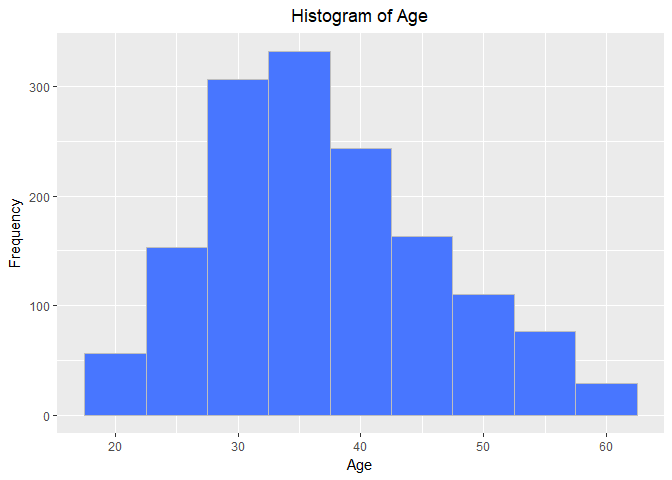

```r
#Create the required histograms
ggplot(data = talentManage, mapping = aes(Age)) +
  geom_histogram(binwidth = 5, color = "gray", fill = "royalblue1" ) +
  labs(x = "Age", y = "Frequency", title = "Histogram of Age") +
  theme(plot.title = element_text(hjust = 0.5))
```

The shape of te histogram resembles a normal distribuiton, with a slight positive bias (mean > median)

And now the histogram of the `Income` and `log(Income)` variable:

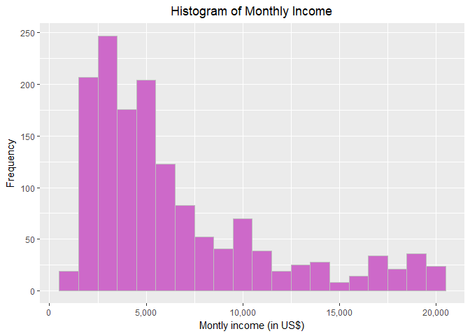

```r
ggplot(data = talentManage, mapping = aes(MonthlyIncm)) +
  geom_histogram(binwidth = 1000, color = "gray", fill = "orchid3" ) +
  labs(x = "Montly income (in US$)", y = "Frequency", title = "Histogram of Monthly Income") +
  scale_x_continuous(label = comma) +
  theme(plot.title = element_text(hjust = 0.5))
```

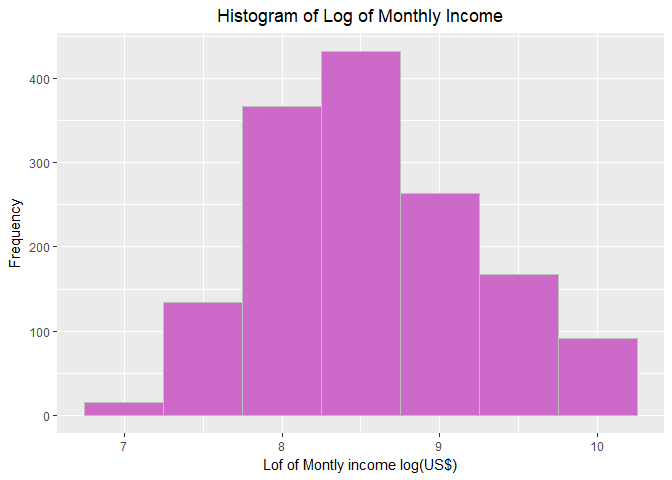

```r
ggplot(talentManage, aes(talentManage$logMthlyInc)) +
  geom_histogram(binwidth=0.5, color="gray", fill="orchid3") +
  labs(x = "Lof of Montly income log(US$)", y = "Frequency", title = "Histogram of Log of Monthly Income") +
  theme(plot.title = element_text(hjust = 0.5))
```

The histogram shows a strong positive skewness, which is typical of Income distributions: a small group of people in the organization have very high salaries. Logarithm of the income gives less skewness so we will proceed with log(MonthlyIncome)

**c Give the frequencies (in table format or similar) for Gender, Education, and Occupation. They can be separate tables, if that’s your choice.**

```r
# Summarize categorical variables with counts

summary_factor <- with(talentManage,
                list("Gender" = tab_summary(factor(Gender)),
                     "Education" = tab_summary(factor(Education)),
                     "Ocupation" = tab_summary(factor(EducatinFld))))

table_factor <- summary_table(talentManage, summary_factor)
table_factor
```

|  | talentManage (N = 1470) |
| --- | --- |
| **Gender** |  |
| Female | 588 (40) |
| Male | 882 (60) |
| **Education** |  |
| Below College | 170 (12) |
| College | 282 (19) |
| Bachelor | 572 (39) |
| Master | 398 (27) |
| Doctor | 48 (3) |
| **Ocupation** |  |
| Human Resources | 27 (2) |
| Life Sciences | 606 (41) |
| Marketing | 159 (11) |
| Medical | 464 (32) |
| Other | 82 (6) |
| Technical Degree | 132 (9) |

**d Give the counts (again, table) of management positions.**

```r
#Management positions are 3 and above:
paste(talentManage$JobRole[110:125], talentManage$JobLevel[110:125], sep = ",")
```

[1] “Laboratory Technician,1” “Healthcare Representative,3” [3] “Laboratory Technician,2” “Manager,4”  
[5] “Laboratory Technician,1” “Research Scientist,2”  
[7] “Sales Executive,3” “Manager,3”  
[9] “Sales Executive,3” “Laboratory Technician,1”  
[11] “Manager,4” “Research Scientist,1”  
[13] “Sales Executive,2” “Research Scientist,1”  
[15] “Research Director,5” “Sales Executive,2”

```r
summary_positions <- with(talentManage,
                     list("Management Positions" = tab_summary(factor(JobLevel[JobLevel == 3 | JobLevel ==4 | JobLevel ==5]))))

table_positions <- summary_table(talentManage, summary_positions)
table_positions
```

|  | talentManage (N = 1470) |
| --- | --- |
| **Management Positions** |  |
| 3 | 218 (55) |
| 4 | 106 (27) |
| 5 | 69 (18) |